# Estimación de las variables que mas impactan en la confianza del consumidor

*El objetivo de esta notebook es entender qué variables influyen en la determinación de la confianza del consumidor, que es un indicador de la predisposicion de los consumidores a gastar. Este indicador se basa en una encuesta a las personas sobre su situación personal, la situacion macroeconomica, y la posibilidad de compra de bienes durables e inmuebles.* mas información en este link [icc_utdt](https://www.utdt.edu/ver_contenido.php?id_contenido=2574&id_item_menu=4979)

Primero corremos las librerias necesarias:

```r
library(readxl)
library(corrplot)
library(lubridate)
```

Importamos las variables de estudio:

```r
fileinput="C:\\ICC\\Confianza.xlsx"
input=read_excel(fileinput, sheet="Hoja1",col_names = TRUE) #variables generales
```

**Descripcion de la variables incluidas en el dataset:**

- ICC: Indice de Confianza del Consumidor
- IGA: Indice General de Actividad (Orlando Ferreres), variable proxy del PBI
- TC: Tipo de cambio (BCRA)
- int_plazo_fijo: tasa de interes de depositos a plazo fijo en pesos
- dep_dls: depositos de las personas en dólares
- GP: Gasto Publico del Gobierno Nacional en terminos nominales
- vtas_came: ventas minoristas (CAME) en cantidades
- infl_esp_moda: moda de inflación esperada de encuesta de expectativas de inflación
- infl_esp_promedio: promedio de inflación esperada de encuesta de expectativas de inflación
- inflación_indice: indice de inflación INDEC
- masa_sal_real: masa salarial de trabajadores del sector formal

Hacemos una vista previa de los datos y un resumen estadístico:

```r
head(input)
```

| fecha | ICC | IGA | TC | int_plazo_fijo | dep_dls | GP | vtas_came | infl_esp_moda | inflacion_indice | infl_esp_promedio | masa_sal_real |
| --- | --- | --- | --- | --- | --- | --- | --- | --- | --- | --- | --- |
| 2013-01-01 | 46.85669 | 159.0487 | 4.947642 | 13.44381 | 7743.484 | 50287.2 | 122.7 | 30 | 253.0364 | 35.33871 | 187074.6 |
| 2013-02-01 | 47.61668 | 150.8109 | 5.008511 | 13.25824 | 7538.250 | 48190.5 | 104.6 | 30 | 256.0729 | 33.01589 | 177979.6 |
| 2013-03-01 | 46.90847 | 169.8146 | 5.087255 | 13.72105 | 7393.871 | 51183.5 | 119.3 | 30 | 260.0164 | 33.45048 | 185123.9 |
| 2013-04-01 | 44.05509 | 178.0640 | 5.153177 | 13.89700 | 7255.200 | 54279.6 | 120.9 | 30 | 263.9687 | 34.20470 | 179281.2 |
| 2013-05-01 | 41.64900 | 184.0449 | 5.235774 | 14.86045 | 7155.645 | 57261.6 | 131.4 | 30 | 268.1130 | 34.92591 | 182431.2 |
| 2013-06-01 | 44.49174 | 174.6963 | 5.330320 | 15.20167 | 6984.433 | 63925.1 | 151.2 | 30 | 272.4832 | 35.28481 | 257008.2 |

```r
summary(input)
```

```
     fecha                          ICC             IGA              TC         int_plazo_fijo
 Min.   :2013-01-01 00:00:00   Min.   :32.10   Min.   :149.5   Min.   : 4.948   Min.   :13.26
 1st Qu.:2014-08-24 06:00:00   1st Qu.:40.88   1st Qu.:163.2   1st Qu.: 8.394   1st Qu.:18.94
 Median :2016-04-16 00:00:00   Median :43.94   Median :170.4   Median :14.609   Median :21.17
 Mean   :2016-04-16 04:12:00   Mean   :44.41   Mean   :169.2   Mean   :16.633   Mean   :24.60
 3rd Qu.:2017-12-08 18:00:00   3rd Qu.:48.28   3rd Qu.:175.7   3rd Qu.:18.047   3rd Qu.:25.98
 Max.   :2019-08-01 00:00:00   Max.   :60.35   Max.   :184.0   Max.   :52.465   Max.   :53.37
                                               NA's   :1
    dep_dls            GP           vtas_came     infl_esp_moda   inflacion_indice
 Min.   : 6621   Min.   : 48191   Min.   : 79.9   Min.   :20.00   Min.   : 253.0
 1st Qu.: 7246   1st Qu.: 94396   1st Qu.:106.0   1st Qu.:25.00   1st Qu.: 408.1
 Median :11801   Median :148999   Median :119.3   Median :30.00   Median : 676.7
 Mean   :15995   Mean   :160216   Mean   :131.0   Mean   :27.71   Mean   : 757.5
 3rd Qu.:25569   3rd Qu.:205266   3rd Qu.:137.2   3rd Qu.:30.00   3rd Qu.: 981.2
 Max.   :31641   Max.   :380217   Max.   :286.3   Max.   :40.00   Max.   :1878.5
                 NA's   :1
 infl_esp_promedio masa_sal_real
 Min.   :22.20     Min.   :142900
 1st Qu.:29.27     1st Qu.:167093
 Median :32.56     Median :173905
 Mean   :32.72     Mean   :182694
 3rd Qu.:35.81     3rd Qu.:182184
 Max.   :41.32     Max.   :260548
                   NA's   :1
```

Tenemos faltantes en el último dato de algunos indicadores, por lo que acotamos la serie hasta el mes maximo al que llegan todas las series:

```r
input=input[!is.na(input$IGA),] #la variable IGA es la que suele tener mas demora de publicacion
```

Corremos coeficiente de correlacion lineal para entender la asociacion lineal entre las variables:

```r
correlacion=cor((input[,2:length(input)]))
correlacion
```

```
                         ICC          IGA         TC int_plazo_fijo     dep_dls          GP
ICC                1.0000000  0.187993508 -0.5928317     -0.5399005 -0.51213773 -0.44176617
IGA                0.1879935  1.000000000 -0.1241661     -0.1687684 -0.02405408 -0.05392948
TC                -0.5928317 -0.124166100  1.0000000      0.9072178  0.87592983  0.89830882
int_plazo_fijo    -0.5399005 -0.168768439  0.9072178      1.0000000  0.62697858  0.75501203
dep_dls           -0.5121377 -0.024054079  0.8759298      0.6269786  1.00000000  0.90569746
GP                -0.4417662 -0.053929482  0.8983088      0.7550120  0.90569746  1.00000000
vtas_came          0.2309523 -0.100785098 -0.2180961     -0.1456947 -0.19560243  0.02491972
infl_esp_moda     -0.3753727 -0.209969973  0.1625382      0.3717670 -0.19459335 -0.11822520
inflacion_indice  -0.5282243 -0.075577903  0.9785465      0.8363466  0.93690673  0.94097741
infl_esp_promedio -0.7256745 -0.215148265  0.2564183      0.3929380 -0.02800467 -0.01519033
masa_sal_real      0.2017432  0.005921264 -0.2743831     -0.2408824 -0.20997258 -0.03399622
                    vtas_came infl_esp_moda inflacion_indice infl_esp_promedio masa_sal_real
ICC                0.23095225  -0.375372695     -0.528224326       -0.72567453   0.201743203
IGA               -0.10078510  -0.209969973     -0.075577903       -0.21514827   0.005921264
TC                -0.21809611   0.162538233      0.978546546        0.25641832  -0.274383149
int_plazo_fijo    -0.14569470   0.371766996      0.836346616        0.39293805  -0.240882384
dep_dls           -0.19560243  -0.194593352      0.936906727       -0.02800467  -0.209972582
GP                 0.02491972  -0.118225196      0.940977414       -0.01519033  -0.033996216
vtas_came          1.00000000  -0.049757821     -0.214768322       -0.09932853   0.693310544
infl_esp_moda     -0.04975782   1.000000000      0.001237503        0.81657933  -0.075692413
inflacion_indice  -0.21476832   0.001237503      1.000000000        0.10830370  -0.256186695
infl_esp_promedio -0.09932853   0.816579334      0.108303695        1.00000000  -0.115629981
masa_sal_real      0.69331054  -0.075692413     -0.256186695       -0.11562998   1.000000000
```

```r
as.data.frame(correlacion[,3])
```

|  | correlacion[, 3] |
| --- | --- |
| ICC | -0.5928317 |
| IGA | -0.1241661 |
| TC | 1.0000000 |
| int_plazo_fijo | 0.9072178 |
| dep_dls | 0.8759298 |
| GP | 0.8983088 |
| vtas_came | -0.2180961 |
| infl_esp_moda | 0.1625382 |
| inflacion_indice | 0.9785465 |
| infl_esp_promedio | 0.2564183 |

[output cut: 1 more lines]

Como se ve la variable tipo de cambio esta muy relacionada con la tasa de interes de los plazos fijos, lo cual puede deberse porque en general a mayor tipo de cambio mayores son las tasas de interés de los plazos fijos para evitar corridas del peso hacia el dólar. Tipo de cambio tambien esta muy correlacionado con depositos en dólares, gasto publico e indice de inflación.

Para intentar solucionar los problemas de correlacion entre features se haran transformaciones con el fin de contrarrestar el ruido de la inflación, deflactando algunas variables de manera de tenerlas en terminos reales.

```r
input2=input #hacemos una copia del dataset
#transformamos las variables
input2$int_plazo_fijo=input$int_plazo_fijo/input$inflacion_indice #transformamos la variable
input2$GP=input$GP/input$inflacion_indice
input2$TC=input$TC/input$inflacion_indice
input2$dep_dls=input$dep_dls*input$TC/input$inflacion_indice #los depositos en dolares los multiplicamos por el tipo de cambio y dividimos por inflación
```

Lo que acabamos de hacer para el caso del tipo de cambio implica que al deflactarlo se pueden detectar mejor los shocks cambiarios por devaluaciones muy por encima de la inflación:

```r
plot(scale(input$TC),type = "o",col = "red")
lines(scale(input$inflacion_indice), type = "o",col = "blue")
```

[figure not shown]

```r
lines(scale(input2$TC), type = "o",col = "green")
```

En el gráfico vemos que la linea azul representa la inflacion desde 2013 hasta 2019, la linea roja la devaluacion y la linea verde el tipo de cambio deflactado, es decir la diferencia entre las anteriores. Se considera que fuertes variaciones en el TC por encima dela inflacion son las que realmente influyen en la confianza del consumidor.

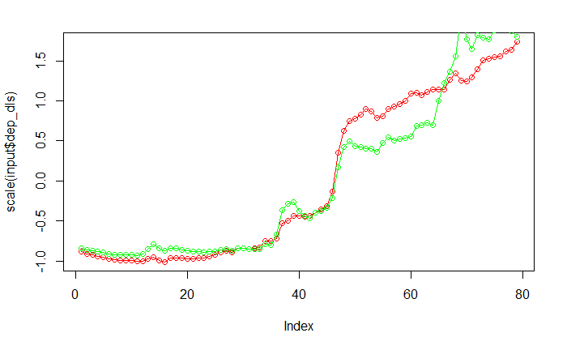

```r
plot(scale(input$dep_dls),type = "o",col = "red")
lines(scale(input2$dep_dls), type = "o",col = "green")
```

En el grafico anterior la linea de color rojo muestra la evolucion de los depositos en dolar expresados en u$s y la linea verde muestra la evolucion de estos mismos depositos llevados a pesos y deflactados por inflacion, de esta manera tenemos una idea de qué parte del dinero en pesos de las personas se destina a ahorrar en dolares en terminos reales.

Ahora volvemos a calcular la matriz de correlaciones:

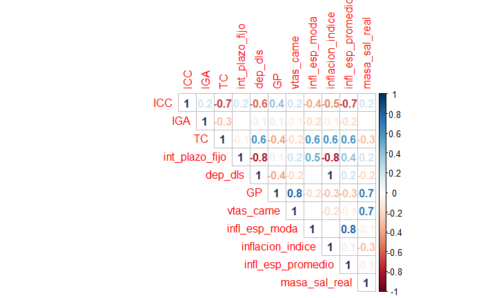

```r
correlacion2<-round(cor(input2[,2:length(input2)]), 1)
corrplot(correlacion2, method="number", type="upper")
```

Una vez corregidas las variables podemos ver que las que mas se relacionan con ICC son tipo de cambio inflación esperada y depositos en dólares de manera negativa y de manera positiva gasto publico en mayor magnitud y en menor magnitud ventas minoristas PBI y masa salarial.

### Modelo de regresion lineal

```r
regresion=lm(ICC~.-fecha-inflacion_indice-infl_esp_moda, data = input2 )
summary(regresion)
```

```
Call:
lm(formula = ICC ~ . - fecha - inflacion_indice - infl_esp_moda,
    data = input2)

Residuals:
    Min      1Q  Median      3Q     Max
-6.8340 -1.8503  0.2867  1.8452  6.9603

Coefficients:
                    Estimate Std. Error t value Pr(>|t|)
(Intercept)        7.631e+01  1.020e+01   7.479 1.66e-10 ***
IGA                3.299e-02  4.761e-02   0.693   0.4906
TC                 2.331e+02  3.644e+02   0.640   0.5245
int_plazo_fijo     9.839e+01  8.695e+01   1.132   0.2617
dep_dls           -1.159e-02  6.526e-03  -1.776   0.0801 .
GP                -1.991e-02  2.402e-02  -0.829   0.4101
vtas_came          2.338e-02  1.466e-02   1.595   0.1152
infl_esp_promedio -1.202e+00  1.288e-01  -9.333 6.51e-14 ***
masa_sal_real     -8.202e-06  1.949e-05  -0.421   0.6751
---
Signif. codes:  0 *** 0.001 ** 0.01 * 0.05 . 0.1   1

Residual standard error: 3.078 on 70 degrees of freedom
Multiple R-squared:  0.8034,    Adjusted R-squared:  0.7809
F-statistic: 35.75 on 8 and 70 DF,  p-value: < 2.2e-16
```

Si bien la metrica R2 arroja un valor aceptable de 78,09% se observa signos de coeficientes erroneos desde el punto de vista economico, como por ejemplo es erroneo que a mayor tipo de cambio mayor confianza del consumidor, o que a mayor tasa de interes mayor ICC. Las variables con signo opuesto al esperado son: TC, tasa de interes, Gasto Publico, masa salarial

```r
regresion1=lm(ICC~.-fecha-inflacion_indice-infl_esp_moda, data = input )
summary(regresion1)
```

```
Call:
lm(formula = ICC ~ . - fecha - inflacion_indice - infl_esp_moda,
    data = input)

Residuals:
    Min      1Q  Median      3Q     Max
-5.9241 -1.4794  0.4268  1.6352  5.0972

Coefficients:
                    Estimate Std. Error t value Pr(>|t|)
(Intercept)        8.728e+01  7.668e+00  11.381  < 2e-16 ***
IGA                4.655e-02  3.665e-02   1.270   0.2083
TC                 6.808e-01  1.999e-01   3.405   0.0011 **
int_plazo_fijo    -1.903e-01  1.387e-01  -1.372   0.1745
dep_dls           -7.056e-04  1.490e-04  -4.734 1.11e-05 ***
GP                -3.209e-05  1.520e-05  -2.112   0.0383 *
vtas_came          2.491e-02  1.029e-02   2.422   0.0180 *
infl_esp_promedio -1.361e+00  9.405e-02 -14.469  < 2e-16 ***
masa_sal_real      2.191e-06  1.525e-05   0.144   0.8862
---
Signif. codes:  0 *** 0.001 ** 0.01 * 0.05 . 0.1   1

Residual standard error: 2.608 on 70 degrees of freedom
Multiple R-squared:  0.8588,    Adjusted R-squared:  0.8427
F-statistic: 53.23 on 8 and 70 DF,  p-value: < 2.2e-16
```

En este caso mejora mucho el R2, pasa a **84,27%**, y las variables con signo opuesto al esperado son: TC y Gasto Publico, lo que implica una mejora significativa en el modelo.

*Ahora convertimos las variables en logaritmo natural para ver si puede mejorar el modelo:*

```r
input3=log(input2[,2:length(input2)])
regresion2=lm(ICC~.-inflacion_indice-infl_esp_moda, data = input3 )
summary(regresion2)
```

```
Call:
lm(formula = ICC ~ . - inflacion_indice - infl_esp_moda, data = input3)

Residuals:
      Min        1Q    Median        3Q       Max
-0.139003 -0.029951  0.002848  0.033813  0.138037

Coefficients:
                  Estimate Std. Error t value Pr(>|t|)
(Intercept)        8.44297    1.27261   6.634 5.76e-09 ***
IGA                0.13031    0.15346   0.849  0.39868
TC                 0.35840    0.22514   1.592  0.11592
int_plazo_fijo    -0.12014    0.10355  -1.160  0.24988
dep_dls           -0.21985    0.07029  -3.128  0.00257 **
GP                -0.18577    0.11953  -1.554  0.12466
vtas_came          0.09407    0.04864   1.934  0.05713 .
infl_esp_promedio -0.87253    0.08074 -10.806  < 2e-16 ***
masa_sal_real      0.03947    0.07808   0.505  0.61480
---
Signif. codes:  0 *** 0.001 ** 0.01 * 0.05 . 0.1   1

Residual standard error: 0.0612 on 70 degrees of freedom
Multiple R-squared:  0.8499,    Adjusted R-squared:  0.8327
F-statistic: 49.55 on 8 and 70 DF,  p-value: < 2.2e-16
```

En el modelo anterior el R2 empeora, pasa de 84,27% a 83,27%, y las variables con signo opuesto al esperado tambien son: TC y Gasto Publico. Dado el tratamiento de las variables los coeficientes del modelo de regresion en este caso son las elasticidades de cada una de las variables respecto a la confianza del consumidor.

Dado que TC esta correlacionado con depositos en dolares eliminamos esta ultima variable y tambien eliminamos del modelo las variables masa_sal_real, IGA e int_plazo_fijo porque son muy poco significativas dentro del modelo (t value menor a 2 en valor absoluto)

```r
input3=log(input2[,2:length(input2)])
regresion3=lm(ICC~.-inflacion_indice-infl_esp_moda-masa_sal_real-IGA-int_plazo_fijo-dep_dls, data = input3 )
summary(regresion3)
```

```
Call:
lm(formula = ICC ~ . - inflacion_indice - infl_esp_moda - masa_sal_real -
    IGA - int_plazo_fijo - dep_dls, data = input3)

Residuals:
      Min        1Q    Median        3Q       Max
-0.200219 -0.067600 -0.000293  0.073687  0.191599

Coefficients:
                   Estimate Std. Error t value Pr(>|t|)
(Intercept)        3.001895   0.819375   3.664 0.000465 ***
TC                -0.528291   0.120561  -4.382 3.82e-05 ***
GP                 0.005329   0.133721   0.040 0.968320
vtas_came          0.075333   0.063013   1.196 0.235698
infl_esp_promedio -0.477035   0.098025  -4.866 6.25e-06 ***
---
Signif. codes:  0 *** 0.001 ** 0.01 * 0.05 . 0.1   1

Residual standard error: 0.08916 on 74 degrees of freedom
Multiple R-squared:  0.6632,    Adjusted R-squared:  0.645
F-statistic: 36.42 on 4 and 74 DF,  p-value: < 2.2e-16
```

En el modelo anterior si bien empeora el R2 que paso a ser 64,5%, todas las variables tienen el signo esperado.

*Ahora probaremos eliminar del modelo la variable TC e incorporar depositos en dolares de las personas (expresados en pesos)*

```r
input3=log(input2[,2:length(input2)])
regresion3=lm(ICC~.-inflacion_indice-infl_esp_moda-masa_sal_real-IGA-int_plazo_fijo-TC, data = input3 )
summary(regresion3)
```

```
Call:
lm(formula = ICC ~ . - inflacion_indice - infl_esp_moda - masa_sal_real -
    IGA - int_plazo_fijo - TC, data = input3)

Residuals:
      Min        1Q    Median        3Q       Max
-0.138432 -0.036214 -0.001271  0.041877  0.122680

Coefficients:
                  Estimate Std. Error t value Pr(>|t|)
(Intercept)        7.55775    0.47999  15.746   <2e-16 ***
dep_dls           -0.12862    0.01141 -11.271   <2e-16 ***
GP                -0.11274    0.09131  -1.235    0.221
vtas_came          0.07079    0.04285   1.652    0.103
infl_esp_promedio -0.80110    0.05393 -14.855   <2e-16 ***
---
Signif. codes:  0 *** 0.001 ** 0.01 * 0.05 . 0.1   1

Residual standard error: 0.06071 on 74 degrees of freedom
Multiple R-squared:  0.8438,    Adjusted R-squared:  0.8354
F-statistic: 99.97 on 4 and 74 DF,  p-value: < 2.2e-16
```

Se obtiene un mejor R2 83,54% pero las variables GP y vtas came no son significativas y GP tiene un coeficiente con signo opuesto al esperado, por lo que volvemos a correr el modelo eliminando esas variables:

```r
input3=log(input2[,2:length(input2)])
regresion4=lm(ICC~.-inflacion_indice-infl_esp_moda-masa_sal_real-IGA-int_plazo_fijo-TC-GP-vtas_came, data = input3 )
summary(regresion4)
```

```
Call:
lm(formula = ICC ~ . - inflacion_indice - infl_esp_moda - masa_sal_real -
    IGA - int_plazo_fijo - TC - GP - vtas_came, data = input3)

Residuals:
      Min        1Q    Median        3Q       Max
-0.149034 -0.040544  0.003456  0.042573  0.127717

Coefficients:
                  Estimate Std. Error t value Pr(>|t|)
(Intercept)        7.23815    0.18489   39.15   <2e-16 ***
dep_dls           -0.12864    0.01061  -12.12   <2e-16 ***
infl_esp_promedio -0.78548    0.05046  -15.57   <2e-16 ***
---
Signif. codes:  0 *** 0.001 ** 0.01 * 0.05 . 0.1   1

Residual standard error: 0.06101 on 76 degrees of freedom
Multiple R-squared:  0.8381,    Adjusted R-squared:  0.8338
F-statistic: 196.7 on 2 and 76 DF,  p-value: < 2.2e-16
```

Finalmente el modelo obtenido no baja practicamente su R2 y se simplifica bastante al tener solo dos variables explicativas. Por lo cual consideramos a este como el mejor modelo.

Ahora corremos de nuevo el que consideramos el mejor moddelo pero variabdo el año de inicio:

```r
#definimos la minima cantidad de años a considerar en el modelo
fin=which(year(input$fecha)==2016)[1] #el periodo mas corto es desde 2016
sec=seq(2,fin,by=12)
for(i in sec )
  {
    regresion=lm(ICC~.-inflacion_indice-infl_esp_moda-IGA-int_plazo_fijo-TC-GP-masa_sal_real-vtas_came, data = input3[i:dim(input3)[1],] )
    print(summary(regresion))
  }
```

```
Call:
lm(formula = ICC ~ . - inflacion_indice - infl_esp_moda - IGA -
    int_plazo_fijo - TC - GP - masa_sal_real - vtas_came, data = input3[i:dim(input3)[1],
    ])

Residuals:
      Min        1Q    Median        3Q       Max
-0.146947 -0.039313  0.003639  0.042011  0.128611

Coefficients:
                  Estimate Std. Error t value Pr(>|t|)
(Intercept)        7.24350    0.18518   39.12   <2e-16 ***
dep_dls           -0.12760    0.01068  -11.94   <2e-16 ***
infl_esp_promedio -0.78890    0.05066  -15.57   <2e-16 ***
---
Signif. codes:  0 *** 0.001 ** 0.01 * 0.05 . 0.1   1

Residual standard error: 0.06107 on 75 degrees of freedom
Multiple R-squared:  0.8395,    Adjusted R-squared:  0.8352
F-statistic: 196.1 on 2 and 75 DF,  p-value: < 2.2e-16


Call:
lm(formula = ICC ~ . - inflacion_indice - infl_esp_moda - IGA -
    int_plazo_fijo - TC - GP - masa_sal_real - vtas_came, data = input3[i:dim(input3)[1],
    ])

Residuals:
      Min        1Q    Median        3Q       Max
-0.142189 -0.042268 -0.000599  0.046116  0.132113

Coefficients:
                  Estimate Std. Error t value Pr(>|t|)
(Intercept)        7.22777    0.19801  36.502  < 2e-16 ***
dep_dls           -0.12382    0.01278  -9.687 4.27e-14 ***
infl_esp_promedio -0.79113    0.05495 -14.397  < 2e-16 ***
---
Signif. codes:  0 *** 0.001 ** 0.01 * 0.05 . 0.1   1

Residual standard error: 0.06462 on 63 degrees of freedom
```

[output cut: 9 more lines]

```
Residuals:
      Min        1Q    Median        3Q       Max
-0.105205 -0.040252  0.001432  0.040417  0.133401

Coefficients:
                  Estimate Std. Error t value Pr(>|t|)
(Intercept)        6.90088    0.19966  34.563  < 2e-16 ***
dep_dls           -0.16075    0.01642  -9.788 2.67e-13 ***
infl_esp_promedio -0.63053    0.06866  -9.183 2.17e-12 ***
---
Signif. codes:  0 *** 0.001 ** 0.01 * 0.05 . 0.1   1

Residual standard error: 0.0569 on 51 degrees of freedom
Multiple R-squared:  0.8871,    Adjusted R-squared:  0.8827
F-statistic: 200.3 on 2 and 51 DF,  p-value: < 2.2e-16
```

*Comparando predicciones con el valor real*

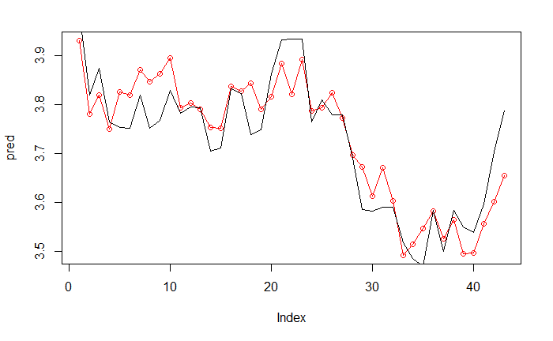

```r
pred=predict(regresion, input3[fin:dim(input3)[1],])
plot(pred, type = "o",col = "red")
lines(input3[fin:dim(input3)[1],1])
```

En el grafico anterior vemos la prediccion del modelo en color rojo y el real en color negro. Ajusta bastante bien.